# E-commerce Revenue Forecasting using ARIMA and LSTM

Tran Nguyen Thanh Nam

2026-06-06

```r
knitr::opts_chunk$set(
  echo = TRUE,
  warning = FALSE,
  message = FALSE,
  fig.align = "center",
  fig.width = 10,
  fig.height = 6
)
```

# Business Understanding

Accurate revenue forecasting is critical for inventory planning, marketing budget allocation, and operational decision-making in e-commerce businesses.

This project analyzes the UCI Online Retail dataset and compares a statistical forecasting approach (ARIMA) with a deep learning approach (LSTM) for predicting future revenue trends.

# Project Objectives

- Clean and transform transaction-level data.
- Aggregate revenue into weekly_revenue and monthly_revenue time series.
- Explore trends and seasonality patterns.
- Develop ARIMA and LSTM forecasting models.
- Compare forecasting performance using MAE, RMSE, and MAPE.
- Generate revenue forecasts for the next 8 weeks.
0. Cài đặt & nạp thư viện

```r
pkgs <- c("readr", "dplyr", "lubridate", "ggplot2", "forecast",
          "tseries", "MASS", "keras", "zoo", "gridExtra")
new_pkgs <- pkgs[!pkgs %in% installed.packages()[,"Package"]]
if (length(new_pkgs)) install.packages(new_pkgs)

library(readr)
library(dplyr)
library(lubridate)
library(ggplot2)
library(forecast)
library(tseries)
library(MASS)
library(keras)
library(zoo)
library(gridExtra)

dir.create("../images", showWarnings = FALSE)
dir.create("../reports", showWarnings = FALSE)
```

BƯỚC 1: NẠP & TIỀN XỬ LÝ DỮ LIỆU

```r
retail_data <- read_csv(
  "../data/online_retail.csv",
  locale = locale(encoding = "latin1")
)

# Làm sạch
retail_data <- retail_data %>%
  mutate(
    InvoiceDate = parse_date_time(InvoiceDate, orders = c("dmy HM", "ymd HM")),
    Revenue     = Quantity * UnitPrice
  ) %>%
  filter(Quantity > 0, UnitPrice > 0, !is.na(InvoiceDate))

cat("Dữ liệu sau làm sạch:", nrow(retail_data), "dòng\n")
```

```
## Dữ liệu sau làm sạch: 227703 dòng
```

```r
cat("Khoảng thời gian:", format(min(retail_data$InvoiceDate)), "→", format(max(retail_data$InvoiceDate)), "\n")
```

```
## Khoảng thời gian: 2010-01-12 08:26:00 → 2011-12-10 17:19:00
```

```r
cat("Tổng doanh thu: £", formatC(sum(retail_data$Revenue), format="f", digits=0, big.mark=","), "\n\n")
```

```
## Tổng doanh thu: £ 4,673,319
```

```r
# ── Chuỗi doanh thu theo tuần ─────────────────────────────────
weekly_revenue <- retail_data %>%
  mutate(Week = floor_date(InvoiceDate, unit = "week")) %>%
  group_by(Week) %>%
  summarise(Revenue = sum(Revenue), .groups = "drop") %>%
  arrange(Week)

# ── Chuỗi doanh thu theo tháng ───────────────────────────────
monthly_revenue <- retail_data %>%
  mutate(Month = floor_date(InvoiceDate, unit = "month")) %>%
  group_by(Month) %>%
  summarise(Revenue = sum(Revenue), .groups = "drop") %>%
  arrange(Month)

cat("Số tuần:", nrow(weekly_revenue), "| Số tháng:", nrow(monthly_revenue), "\n\n")
```

```
## Số tuần: 39 | Số tháng: 22
```

BƯỚC 2: PHÂN TÍCH KHÁM PHÁ (EDA)

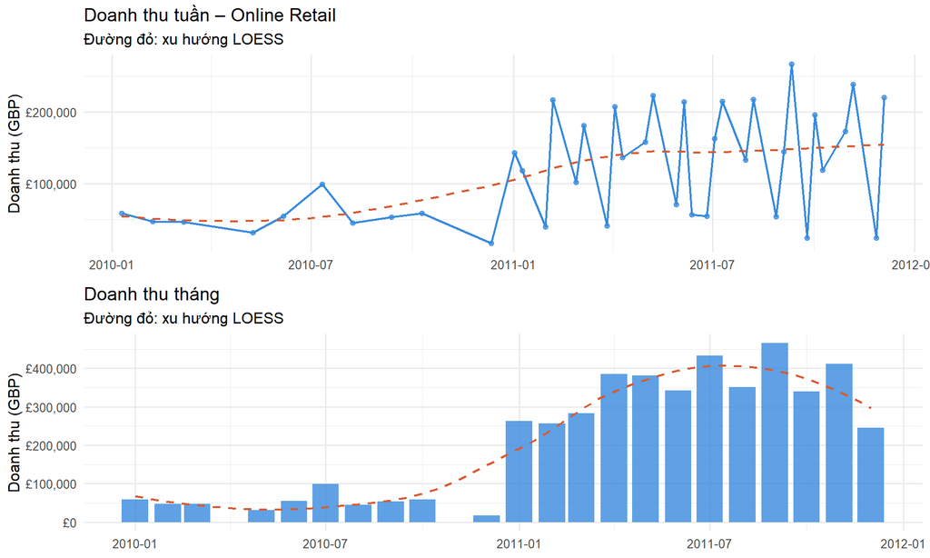

```r
# Vẽ chuỗi doanh thu tuần
p1 <- ggplot(weekly_revenue, aes(x = Week, y = Revenue)) +
  geom_line(color = "#378ADD", linewidth = 0.8) +
  geom_point(color = "#378ADD", size = 1.5, alpha = 0.7) +
  geom_smooth(method = "loess", se = FALSE, color = "#D85A30",
              linewidth = 0.8, linetype = "dashed") +
  scale_y_continuous(labels = scales::comma_format(prefix = "£")) +
  labs(title = "Doanh thu tuần – Online Retail",
       subtitle = "Đường đỏ: xu hướng LOESS",
       x = NULL, y = "Doanh thu (GBP)") +
  theme_minimal(base_size = 12)

# Vẽ doanh thu tháng
p2 <- ggplot(monthly_revenue, aes(x = Month, y = Revenue)) +
  geom_col(fill = "#378ADD", alpha = 0.8) +
  geom_smooth(method = "loess", se = FALSE, color = "#D85A30",
              linewidth = 0.8, linetype = "dashed") +
  scale_y_continuous(labels = scales::comma_format(prefix = "£")) +
  labs(title = "Doanh thu tháng",
       subtitle = "Đường đỏ: xu hướng LOESS",
       x = NULL, y = "Doanh thu (GBP)") +
  theme_minimal(base_size = 12)

grid.arrange(p1, p2, ncol = 1)
```

```r
ggsave(
  "../images/revenue_trend.png",
  plot = p1,
  width = 10,
  height = 6,
  dpi = 300
)

ggsave(
  "../images/monthly_revenue.png",
  plot = p2,
  width = 10,
  height = 6,
  dpi = 300
)
```

BƯỚC 3: CHUẨN BỊ CHUỖI THỜI GIAN

```r
weekly_ts <- ts(weekly_revenue$Revenue, frequency = 52)

cat("=== KIỂM ĐỊNH ADF ===\n")
```

```
## === KIỂM ĐỊNH ADF ===
```

```r
# ADF cho chuỗi gốc
adf_orig <- adf.test(weekly_ts)

cat(
  "Chuỗi gốc: ADF =",
  round(adf_orig$statistic, 4),
  "| p-value =",
  round(adf_orig$p.value, 4),
  ifelse(
    adf_orig$p.value > 0.05,
    "→ NON-STATIONARY\n",
    "→ STATIONARY\n"
  )
)
```

```
## Chuỗi gốc: ADF = -2.9372 | p-value = 0.2063 → NON-STATIONARY
```

```r
# Sai phân bậc 1
ts_diff <- diff(weekly_ts)

adf_diff <- adf.test(ts_diff)

cat(
  "Sau sai phân d=1: ADF =",
  round(adf_diff$statistic, 4),
  "| p-value =",
  round(adf_diff$p.value, 4),
  ifelse(
    adf_diff$p.value < 0.05,
    "→ STATIONARY ✓\n\n",
    "→ CẦN DIFF THÊM\n\n"
  )
)
```

```
## Sau sai phân d=1: ADF = -5.8666 | p-value = 0.01 → STATIONARY ✓
```

```r
# ACF & PACF
png(
  "../images/stationarity_check.png",
  width = 1200,
  height = 1000
)

par(mfrow = c(2,2))

acf(
  weekly_ts,
  lag.max = 30,
  main = "ACF - Original Series"
)

pacf(
  weekly_ts,
  lag.max = 30,
  main = "PACF - Original Series"
)

acf(
  ts_diff,
  lag.max = 30,
  main = "ACF - Differenced Series"
)

pacf(
  ts_diff,
  lag.max = 30,
  main = "PACF - Differenced Series"
)

par(mfrow = c(1,1))

dev.off()
```

BƯỚC 4: MÔ HÌNH ARIMA

```r
cat("FIT MÔ HÌNH ARIMA\n")
```

```
## FIT MÔ HÌNH ARIMA
```

```r
# 4a. Grid search AIC tốt nhất
best_aic   <- Inf
best_order <- c(1, 1, 1)

for (p in 0:3) {
  for (d in 0:1) {
    for (q in 0:3) {
      tryCatch({
        m   <- Arima(weekly_ts, order = c(p, d, q))
        if (m$aic < best_aic) {
          best_aic   <- m$aic
          best_order <- c(p, d, q)
        }
      }, error = function(e) NULL)
    }
  }
}

cat("Mô hình ARIMA tốt nhất: ARIMA(",
    paste(best_order, collapse = ","), ")  AIC =", round(best_aic, 2), "\n")
```

```
## Mô hình ARIMA tốt nhất: ARIMA( 2,1,2 )  AIC = 956.23
```

```r
# 4b. Fit mô hình tốt nhất
model_arima <- Arima(weekly_ts, order = best_order)
print(summary(model_arima))
```

```
## Series: weekly_ts
## ARIMA(2,1,2)
##
## Coefficients:
##           ar1      ar2     ma1      ma2
##       -1.4035  -0.5845  0.3252  -0.6748
## s.e.   0.1379   0.1379  0.1705   0.1454
##
## sigma^2 = 3.854e+09:  log likelihood = -473.11
## AIC=956.23   AICc=958.1   BIC=964.42
##
## Training set error measures:
##                    ME     RMSE      MAE       MPE     MAPE MASE        ACF1
## Training set 11385.16 57965.73 44924.39 -25.81148 59.66156  NaN -0.07278661
```

```r
# 4c. Kiểm tra phần dư
cat("\n--- Phân tích phần dư ARIMA ---\n")
```

```
##
## --- Phân tích phần dư ARIMA ---
```

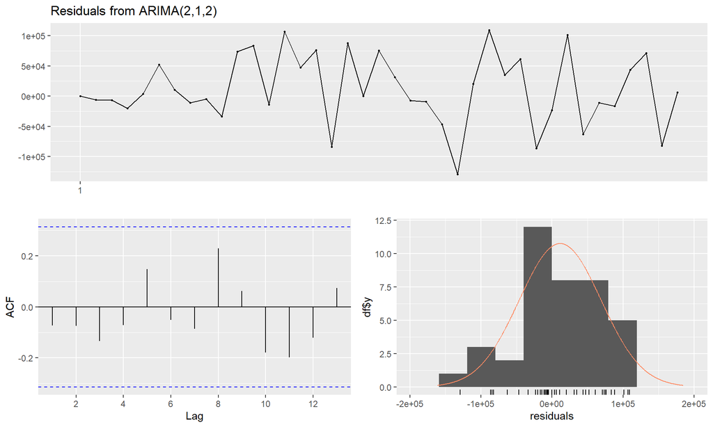

```
##
##  Ljung-Box test
##
## data:  Residuals from ARIMA(2,1,2)
## Q* = 5.737, df = 4, p-value = 0.2197
##
## Model df: 4.   Total lags used: 8
```

```r
checkresiduals(model_arima)
```

```r
# Ljung-Box
lb <- Box.test(resid(model_arima), lag = 20, type = "Ljung-Box")
cat("Ljung-Box p-value:", round(lb$p.value, 4),
    ifelse(lb$p.value > 0.05,
           "→ Phần dư là white noise ✓\n\n",
           "→ Còn tự tương quan trong phần dư\n\n"))
```

```
## Ljung-Box p-value: 0.7043 → Phần dư là white noise ✓
```

```r
# 4d. Độ chính xác trên tập test (80/20)
n_test    <- floor(length(weekly_ts) * 0.2)
ts_train  <- head(weekly_ts, length(weekly_ts) - n_test)
ts_test   <- tail(weekly_ts, n_test)

arima_fit  <- Arima(ts_train, order = best_order)
arima_pred <- forecast(arima_fit, h = n_test)$mean

arima_mae  <- mean(abs(ts_test - arima_pred))
arima_rmse <- sqrt(mean((ts_test - arima_pred)^2))
arima_mape <- mean(abs((ts_test - arima_pred) / ts_test)) * 100

cat("=== ĐỘ CHÍNH XÁC ARIMA (test set) ===\n")
```

```
## === ĐỘ CHÍNH XÁC ARIMA (test set) ===
```

```r
cat("MAE  =", formatC(arima_mae,  format = "f", digits = 0, big.mark = ","), "\n")
```

```
## MAE  = 63,914
```

```r
cat("RMSE =", formatC(arima_rmse, format = "f", digits = 0, big.mark = ","), "\n")
```

```
## RMSE = 76,347
```

```r
cat("MAPE =", round(arima_mape, 2), "%\n\n")
```

```
## MAPE = 154.96 %
```

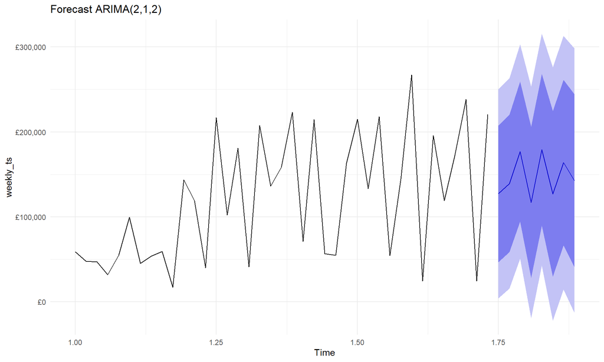

```r
# 4e. Dự báo 8 tuần tới
arima_full <- Arima(weekly_ts, order = best_order)
arima_fc   <- forecast(arima_full, h = 8)

p_arima <- autoplot(arima_fc) +
  scale_y_continuous(
    labels = scales::comma_format(prefix = "£")
  ) +
  labs(
    title = paste0(
      "Forecast ARIMA(",
      paste(best_order, collapse = ","),
      ")"
    )
  ) +
  theme_minimal()

p_arima
```

```r
ggsave(
  "../images/arima_forecast.png",
  plot = p_arima,
  width = 10,
  height = 6,
  dpi = 300
)
```

BƯỚC 5: MÔ HÌNH LSTM (keras)

```r
weekly_ts <- ts(weekly_revenue$Revenue, frequency = 52)
cat("FIT MÔ HÌNH LSTM\n")
```

```
## FIT MÔ HÌNH LSTM
```

```r
library(keras)
library(magrittr)

# 5a. Chuẩn hoá MinMax
ts_vals  <- as.numeric(weekly_ts)
ts_min   <- min(ts_vals)
ts_max   <- max(ts_vals)
ts_scale <- (ts_vals - ts_min) / (ts_max - ts_min)

# 5b. Tạo sequences
LOOK_BACK <- 8

make_sequences <- function(data, lb) {
  n <- length(data) - lb
  X <- matrix(0, nrow = n, ncol = lb)
  y <- numeric(n)
  for (i in seq_len(n)) {
    X[i, ] <- data[i:(i + lb - 1)]
    y[i]   <- data[i + lb]
  }
  list(X = X, y = y)
}

seqs    <- make_sequences(ts_scale, LOOK_BACK)
X_all   <- seqs$X
y_all   <- seqs$y
split_i <- floor(nrow(X_all) * 0.8)

X_train <- array(X_all[1:split_i, ],
                 dim = c(split_i, LOOK_BACK, 1))
y_train <- y_all[1:split_i]

X_test  <- array(X_all[(split_i+1):nrow(X_all), ],
                 dim = c(nrow(X_all) - split_i, LOOK_BACK, 1))
y_test  <- y_all[(split_i+1):length(y_all)]

# 5c. Xây dựng & huấn luyện mô hình
set.seed(42)

model_lstm <- keras_model_sequential() %>%
  layer_lstm(units = 64, return_sequences = TRUE,
             input_shape = c(LOOK_BACK, 1)) %>%
  layer_dropout(rate = 0.2) %>%
  layer_lstm(units = 32) %>%
  layer_dropout(rate = 0.2) %>%
  layer_dense(units = 1)

model_lstm %>% compile(
  optimizer = optimizer_adam(),
  loss      = "mean_squared_error"
)

summary(model_lstm)
```

```
## Model: "sequential"
## ________________________________________________________________________________
##  Layer (type)                       Output Shape                    Param #
## ================================================================================
##  lstm_1 (LSTM)                      (None, 8, 64)                   16896
##  dropout_1 (Dropout)                (None, 8, 64)                   0
##  lstm (LSTM)                        (None, 32)                      12416
##  dropout (Dropout)                  (None, 32)                      0
##  dense (Dense)                      (None, 1)                       33
## ================================================================================
## Total params: 29345 (114.63 KB)
## Trainable params: 29345 (114.63 KB)
## Non-trainable params: 0 (0.00 Byte)
## ________________________________________________________________________________
```

```r
history <- model_lstm %>% fit(
  X_train, y_train,
  epochs          = 50,   # giảm để chạy nhẹ hơn
  batch_size      = 4,
  validation_data = list(X_test, y_test),
  verbose         = 1
)
# Vẽ learning curve
png(
  "../images/lstm_learning_curve.png",
  width = 1200,
  height = 800
)

plot(history)

dev.off()
```

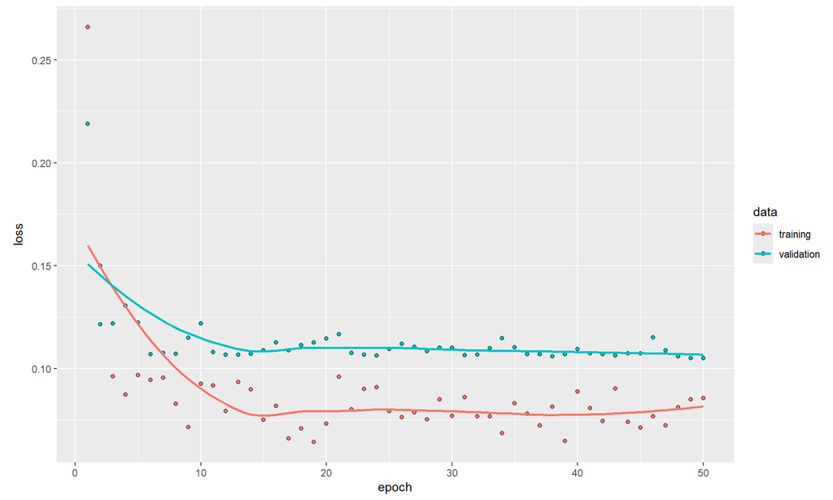

```r
plot(history)
```

```r
# 5d. Đánh giá trên tập test
lstm_pred_scale <- model_lstm %>% predict(X_test) %>% as.vector()
```

```
## 1/1 - 1s - 532ms/epoch - 532ms/step
```

```r
lstm_pred   <- lstm_pred_scale * (ts_max - ts_min) + ts_min
lstm_actual <- y_test          * (ts_max - ts_min) + ts_min

lstm_mae  <- mean(abs(lstm_actual - lstm_pred))
lstm_rmse <- sqrt(mean((lstm_actual - lstm_pred)^2))
lstm_mape <- mean(abs((lstm_actual - lstm_pred) / lstm_actual)) * 100

cat("=== ĐỘ CHÍNH XÁC LSTM (test set) ===\n")
```

```
## === ĐỘ CHÍNH XÁC LSTM (test set) ===
```

```r
cat("MAE  =", formatC(lstm_mae,  format = "f", digits = 0, big.mark = ","), "\n")
```

```
## MAE  = 72,806
```

```r
cat("RMSE =", formatC(lstm_rmse, format = "f", digits = 0, big.mark = ","), "\n")
```

```
## RMSE = 80,964
```

```r
cat("MAPE =", round(lstm_mape, 2), "%\n\n")
```

```
## MAPE = 154.83 %
```

```r
# 5e. Dự báo 8 tuần tới
seq_fc      <- tail(ts_scale, LOOK_BACK)
lstm_future <- numeric(8)

for (i in 1:8) {
  x_in           <- array(seq_fc, dim = c(1, LOOK_BACK, 1))
  p              <- model_lstm %>% predict(x_in) %>% as.numeric()
  lstm_future[i] <- p
  seq_fc         <- c(seq_fc[-1], p)
}
```

```
## 1/1 - 0s - 14ms/epoch - 14ms/step
## 1/1 - 0s - 23ms/epoch - 23ms/step
## 1/1 - 0s - 8ms/epoch - 8ms/step
## 1/1 - 0s - 13ms/epoch - 13ms/step
## 1/1 - 0s - 0s/epoch - 0s/step
## 1/1 - 0s - 13ms/epoch - 13ms/step
## 1/1 - 0s - 17ms/epoch - 17ms/step
## 1/1 - 0s - 4ms/epoch - 4ms/step
```

```r
lstm_fc <- lstm_future * (ts_max - ts_min) + ts_min

cat("Dự báo 8 tuần tới (GBP):\n")
```

```
## Dự báo 8 tuần tới (GBP):
```

```r
print(round(lstm_fc, 0))
```

```
## [1] 145667 139246 147098 144070 145516 143561 137938 145031
```

BƯỚC 6: SO SÁNH & VISUALISE

```r
cat("=== SO SÁNH MÔ HÌNH ===\n")
```

```
## === SO SÁNH MÔ HÌNH ===
```

```r
cat(sprintf("%-10s  MAE=%s   RMSE=%s   MAPE=%.2f%%\n",
            paste0("ARIMA(", paste(best_order, collapse=","), ")"),
            formatC(arima_mae,  format="f", digits=0, big.mark=","),
            formatC(arima_rmse, format="f", digits=0, big.mark=","),
            arima_mape))
```

```
## ARIMA(2,1,2)  MAE=63,914   RMSE=76,347   MAPE=154.96%
```

```r
cat(sprintf("%-10s  MAE=%s   RMSE=%s   MAPE=%.2f%%\n",
            "LSTM",
            formatC(lstm_mae,  format="f", digits=0, big.mark=","),
            formatC(lstm_rmse, format="f", digits=0, big.mark=","),
            lstm_mape))
```

```
## LSTM        MAE=72,806   RMSE=80,964   MAPE=154.83%
```

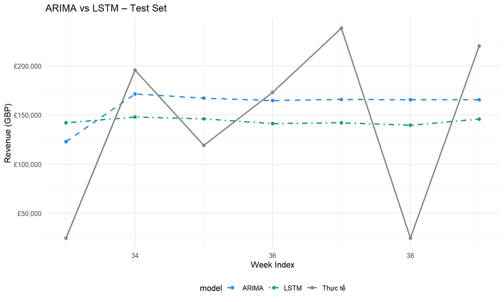

```r
# ── Vẽ Actual vs Predicted (test set) ────────────────────────
n_test_lstm <- length(lstm_pred)
idx_test    <- (length(ts_vals) - n_test + 1):length(ts_vals)
idx_lstm    <- tail(idx_test, n_test_lstm)

retail_data_compare <- data.frame(
  idx    = c(idx_test, idx_lstm, idx_lstm),
  val    = c(ts_test, as.numeric(arima_pred), lstm_pred),
  model  = c(rep("Thực tế",   n_test),
             rep("ARIMA",     n_test),
             rep("LSTM",      n_test_lstm))
)

p_compare <- ggplot(
  retail_data_compare,
  aes(
    x = idx,
    y = val,
    color = model,
    linetype = model
  )
) +
  geom_line(linewidth = 1) +
  geom_point(size = 2) +
  scale_color_manual(
    values = c(
      "Thực tế" = "#888780",
      "ARIMA"   = "#378ADD",
      "LSTM"    = "#1D9E75"
    )
  ) +
  scale_linetype_manual(
    values = c(
      "Thực tế" = "solid",
      "ARIMA"   = "dashed",
      "LSTM"    = "dotdash"
    )
  ) +
  scale_y_continuous(
    labels = scales::comma_format(prefix = "£")
  ) +
  labs(
    title = "ARIMA vs LSTM – Test Set",
    x = "Week Index",
    y = "Revenue (GBP)"
  ) +
  theme_minimal(base_size = 12) +
  theme(
    legend.position = "bottom"
  )

p_compare
```

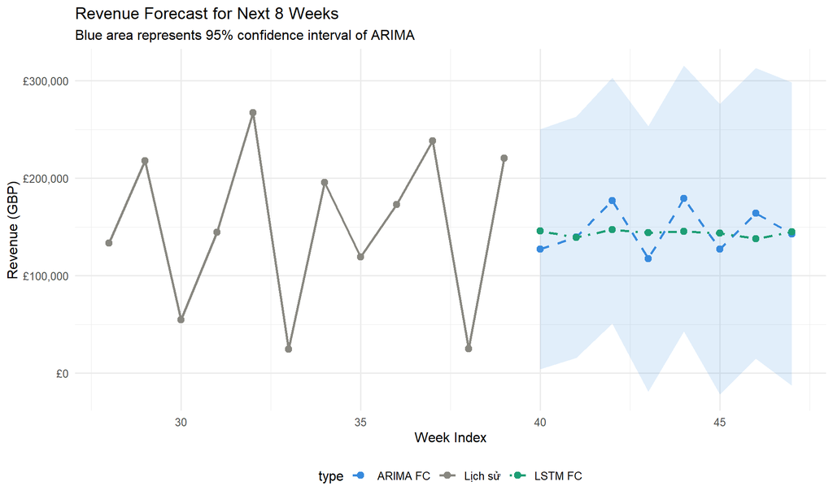

```r
ggsave(
  filename = "../images/model_comparison.png",
  plot = p_compare,
  width = 10,
  height = 6,
  dpi = 300
)

# ── Vẽ dự báo 8 tuần tới ─────────────────────────────────────
n_hist <- 12
hist_idx <- tail(seq_along(ts_vals), n_hist)
fc_idx   <- (length(ts_vals) + 1):(length(ts_vals) + 8)

retail_data_fc <- data.frame(
  idx   = c(hist_idx, fc_idx, fc_idx),
  val   = c(tail(ts_vals, n_hist), as.numeric(arima_fc$mean), lstm_fc),
  type  = c(rep("Lịch sử",   n_hist),
            rep("ARIMA FC",  8),
            rep("LSTM FC",   8))
)

# Khoảng tin cậy ARIMA
retail_data_ci <- data.frame(
  idx  = fc_idx,
  lo   = as.numeric(arima_fc$lower[, 2]),
  hi   = as.numeric(arima_fc$upper[, 2])
)

p_forecast <- ggplot() +

  geom_ribbon(
    data = retail_data_ci,
    aes(
      x = idx,
      ymin = lo,
      ymax = hi
    ),
    fill = "#378ADD",
    alpha = 0.15
  ) +

  geom_line(
    data = retail_data_fc,
    aes(
      x = idx,
      y = val,
      color = type,
      linetype = type
    ),
    linewidth = 1
  ) +

  geom_point(
    data = retail_data_fc,
    aes(
      x = idx,
      y = val,
      color = type
    ),
    size = 2.5
  ) +

  scale_color_manual(
    values = c(
      "Lịch sử"  = "#888780",
      "ARIMA FC" = "#378ADD",
      "LSTM FC"  = "#1D9E75"
    )
  ) +

  scale_linetype_manual(
    values = c(
      "Lịch sử"  = "solid",
      "ARIMA FC" = "dashed",
      "LSTM FC"  = "dotdash"
    )
  ) +

  scale_y_continuous(
    labels = scales::comma_format(prefix = "£")
  ) +

  labs(
    title = "Revenue Forecast for Next 8 Weeks",
    subtitle = "Blue area represents 95% confidence interval of ARIMA",
    x = "Week Index",
    y = "Revenue (GBP)"
  ) +

  theme_minimal(base_size = 12) +

  theme(
    legend.position = "bottom"
  )

p_forecast
```

```r
ggsave(
  filename = "../images/forecast_8weeks.png",
  plot = p_forecast,
  width = 10,
  height = 6,
  dpi = 300
)
```

BƯỚC 7: IN KẾT QUẢ DỰ BÁO

```r
last_date <- max(weekly_revenue$Week)
fc_dates  <- last_date + weeks(1:8)

cat("\n=== DỰ BÁO 8 TUẦN TỚI ===\n")
```

```
##
## === DỰ BÁO 8 TUẦN TỚI ===
```

```r
cat(sprintf("%-15s  %12s  %12s  %12s  %12s\n",
            "Tuần", "ARIMA", "CI Lo 95%", "CI Hi 95%", "LSTM"))
```

```
## Tuần                  ARIMA     CI Lo 95%     CI Hi 95%          LSTM
```

```r
cat(strrep("-", 70), "\n")
for (i in 1:8) {
  cat(sprintf("%-15s  %12s  %12s  %12s  %12s\n",
              format(fc_dates[i], "%d/%m/%Y"),
              paste0("£", formatC(arima_fc$mean[i],   format="f", digits=0, big.mark=",")),
              paste0("£", formatC(arima_fc$lower[i,2],format="f", digits=0, big.mark=",")),
              paste0("£", formatC(arima_fc$upper[i,2],format="f", digits=0, big.mark=",")),
              paste0("£", formatC(lstm_fc[i],          format="f", digits=0, big.mark=","))))
}
```

```
## 11/12/2011          £127,299       £4,195     £250,404     £145,667
## 18/12/2011          £139,358      £15,655     £263,062     £139,246
## 25/12/2011          £176,842      £50,734     £302,949     £147,098
## 01/01/2012          £117,184     £-19,089     £253,458     £144,070
## 08/01/2012          £179,005      £42,518     £315,491     £145,516
## 15/01/2012          £127,109     £-21,987     £276,206     £143,561
## 22/01/2012          £163,811      £14,714     £312,907     £137,938
## 29/01/2012          £142,633     £-13,025     £298,292     £145,031
```

```r
cat("\n=== HOÀN THÀNH ===\n")
```

```
##
## === HOÀN THÀNH ===
```

# Conclusion

This project developed and evaluated ARIMA and LSTM models for e-commerce revenue forecasting.

Key contributions: - End-to-end data cleaning and preprocessing pipeline. - Statistical validation using Augmented Dickey-Fuller (ADF) stationarity testing. - Comparison of traditional and deep learning forecasting methods. - Practical business-oriented revenue forecasts for future planning.

Future improvements may include Prophet, XGBoost, external economic variables, holiday effects, and deployment through a Shiny dashboard.